# Lista03 - EDA

## Lista 03 - EDA - Análise da base de dados da NBA

Beatriz Amancio Sofal;

Igor Galvão;

Victor Covello;

Vitor Publio;

A base utilizada contém estatísticas individuais de jogadores de basquete, a cada uma dentre 67 temporadas da NBA, desde o ano de 1950. O objetivo é fazer a análise exploratória e tirar conclusões sobre o comportamento dos dados.

Dados disponíveis em: https://www.kaggle.com/drgilermo/nba-players-stats

```python
import pandas as pd
import numpy as np
import matplotlib.pyplot as plt
import seaborn as sns

%matplotlib inline
```

```python
dados = pd.read_csv('C:\\Users\\130289\\Desktop\\Beatriz - Distribuição\\A Graduação\\Introdução ao Python\\Lista 03 - EDA\\Seasons_Stats.csv')

#dados.info()
dados.head(4)
```

|  | Unnamed: 0 | Year | Player | Pos | Age | Tm | G | GS | MP | PER | ... | FT% | ORB | DRB | TRB | AST | STL | BLK | TOV | PF | PTS |
| --- | --- | --- | --- | --- | --- | --- | --- | --- | --- | --- | --- | --- | --- | --- | --- | --- | --- | --- | --- | --- | --- |
| 0 | 0 | 1950.0 | Curly Armstrong | G-F | 31.0 | FTW | 63.0 | NaN | NaN | NaN | ... | 0.705 | NaN | NaN | NaN | 176.0 | NaN | NaN | NaN | 217.0 | 458.0 |
| 1 | 1 | 1950.0 | Cliff Barker | SG | 29.0 | INO | 49.0 | NaN | NaN | NaN | ... | 0.708 | NaN | NaN | NaN | 109.0 | NaN | NaN | NaN | 99.0 | 279.0 |
| 2 | 2 | 1950.0 | Leo Barnhorst | SF | 25.0 | CHS | 67.0 | NaN | NaN | NaN | ... | 0.698 | NaN | NaN | NaN | 140.0 | NaN | NaN | NaN | 192.0 | 438.0 |
| 3 | 3 | 1950.0 | Ed Bartels | F | 24.0 | TOT | 15.0 | NaN | NaN | NaN | ... | 0.559 | NaN | NaN | NaN | 20.0 | NaN | NaN | NaN | 29.0 | 63.0 |

4 rows × 53 columns

```python
dados.isna().sum(axis=0)
```

```
Unnamed: 0        0
Year             67
Player           67
Pos              67
Age              75
Tm               67
G                67
GS             6458
MP              553
PER             590
TS%             153
3PAr           5852
FTr             166
ORB%           3899
DRB%           3899
TRB%           3120
AST%           2136
STL%           3899
BLK%           3899
TOV%           5109
USG%           5051
blanl         24691
OWS             106
DWS             106
WS              106
WS/48           590
blank2        24691
OBPM           3894
DBPM           3894
BPM            3894
VORP           3894
FG               67
FGA              67
FG%             166
3P             5764
3PA            5764
3P%            9275
2P               67
2PA              67
2P%             195
eFG%            166
FT               67
FTA              67
FT%             925
ORB            3894
DRB            3894
TRB             379
AST              67
STL            3894
BLK            3894
TOV            5046
PF               67
PTS              67
dtype: int64
```

Como algumas colunas da base de dados possuem estatísticas secundárias com muitos valors nulos, elas não serão incluídas na análise.

```python
dados = dados.drop(columns = ["TOV", "BLK", "STL", "DRB", "ORB", "3P", "3PA", "3P%", "VORP", "BPM",
                              "DBPM", "OBPM", "blank2", "blanl", "ORB%", "DRB%", "TRB%", "AST%",
                             "STL%", "BLK%", "TOV%", "USG%", "3PAr", "GS"])
```

```python
dados.isna().sum(axis=0)
```

```
Unnamed: 0      0
Year           67
Player         67
Pos            67
Age            75
Tm             67
G              67
MP            553
PER           590
TS%           153
FTr           166
OWS           106
DWS           106
WS            106
WS/48         590
FG             67
FGA            67
FG%           166
2P             67
2PA            67
2P%           195
eFG%          166
FT             67
FTA            67
FT%           925
TRB           379
AST            67
PF             67
PTS            67
dtype: int64
```

### Análise pontuação

```python
MediaPontosPlayer = dados[['PTS', 'MP', 'Player']].groupby('Player').mean().sort_values('PTS', ascending=False).round(2)
MediaPontosPlayer.head(7)
```

| Player | PTS | MP |
| --- | --- | --- |
| Michael Jordan* | 2152.80 | 2734.07 |
| Wilt Chamberlain* | 2122.06 | 3197.50 |
| George Gervin* | 2070.80 | 2653.60 |
| LeBron James | 2056.21 | 2948.00 |
| Karl Malone* | 1943.58 | 2886.95 |
| Kareem Abdul-Jabbar* | 1919.35 | 2872.30 |
| Kevin Durant | 1912.10 | 2627.80 |

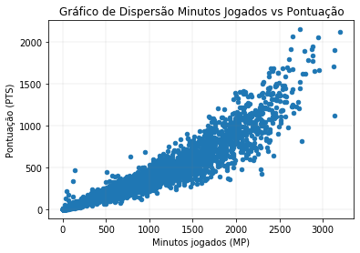

```python
gr = MediaPontosPlayer.plot.scatter(x='MP',y='PTS')
gr.set_title('Gráfico de Dispersão Minutos Jogados vs Pontuação')
gr.set_xlabel('Minutos jogados (MP)')
gr.set_ylabel('Pontuação (PTS)')
gr.grid(color='grey', linestyle='-', linewidth=0.25, alpha=0.5)
```

Foram agrupados os dados de pontuação (PTS) e minutos jogados por jogador (MP). Consideramos no group by o cálculo da média ao inves de soma, pois assim a análise não sofre interferência de jogadores que tenham jogado mais temporadas.

O gráfico de dispersão entre a pontuação e minutos jogados indica evidência de correlação positiva entre as variáveis, próxima de ser linear. Ou seja, aumentando se os minutos jogados, maior a pontuação do atleta.

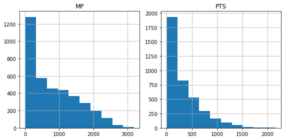

```python
MediaPontosPlayer[['PTS','MP']].hist(figsize=(8,4))
#plt.show()
plt.tight_layout()
```

### Análise Posição

```python
MediaPontosPos = dados[['PTS', 'MP', 'Pos']].groupby('Pos').mean().sort_values('PTS', ascending=False).round(2)
MediaPontosPos.head(10)
```

| Pos | PTS | MP |
| --- | --- | --- |
| SG-PF | 1152.00 | 2480.33 |
| PG-SF | 1022.00 | 2497.00 |
| SF | 563.56 | 1263.98 |
| SG | 562.70 | 1240.43 |
| SF-SG | 561.90 | 1346.03 |
| SF-PG | 543.00 | 1610.00 |
| PG | 509.37 | 1258.09 |
| PF | 500.18 | 1198.73 |
| PG-SG | 462.86 | 1136.68 |
| SF-PF | 454.62 | 1140.67 |

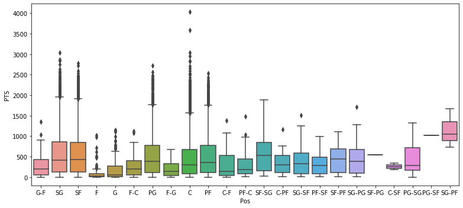

```python
plt.figure(figsize=(11,5))
sns.boxplot(x='Pos',y='PTS',data=dados)
#plt.show()

plt.tight_layout()
```

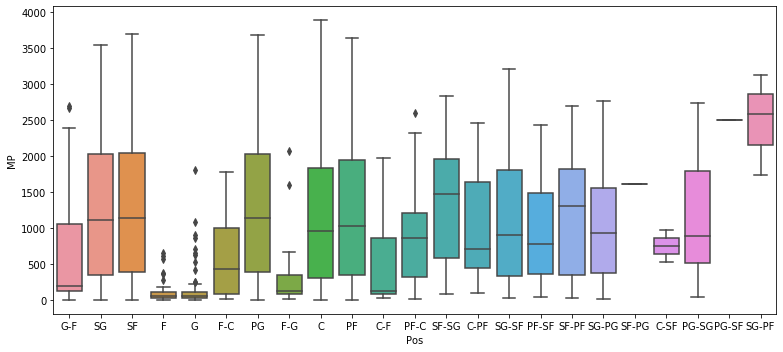

```python
plt.figure(figsize=(11,5))
sns.boxplot(x='Pos',y='MP',data=dados)
#plt.show()

plt.tight_layout()
```

O gráfico de pizza abaixo apresenta a representatividade de cada posição dentro da base de dados. De forma geral, as posições do basquete são: PG - Point Guard (armador), Shooting Guard - SG, Small Forward - SF, Power Forward - PF e Center (pivô) - C.

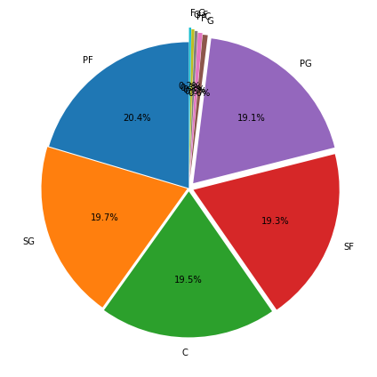

```python
x = pd.value_counts(dados['Pos'])
cat = x[:10].index.values
freq = x[:10].values

np.append(cat, 'Others')
np.append(freq, np.sum(x[10:]))

plt.figure(figsize=(6,6))
plt.pie(freq, labels=cat, explode=np.linspace(0,0.1,10),startangle=90,autopct='%1.1f%%')
#plt.show()
plt.tight_layout()
```

### Análise por idade

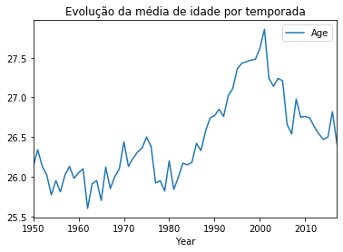

```python
MediaIdadeAno = dados[["Age","Year"]].groupby('Year').mean().sort_values('Year', ascending=False).round(2)

gr2 = MediaIdadeAno.plot(kind = 'line')
gr2.set_title('Evolução da média de idade por temporada')
```

O gráfico acima mostra a evolução da média de idade dos jogadores da liga ao longo das temporadas da NBA. Percebe-se o aumento de 2 anos na média da década de 60 até os anos 2000, valor significativo tendo em vista a curta carreira de um atleta profissional de alto nível.

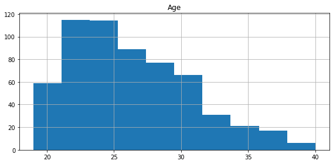

```python
aux = dados.loc[dados["Year"] == 2017, ]

aux[['Age']].hist(figsize=(8,4))
#plt.show()
plt.tight_layout()
```

O histograma acima indica a distribuição das idades dos jogadores para a temporada mais recente da base. Percebe-se grande concentração de valores ocorre para os anos mais recentes da carreira, até os 25 anos.

### Ressalvas

O histograma abaixo indica os dados estratificados por ano. Para os anos mais recentes, o volume de dados é superior ao das décadas mais antigas.

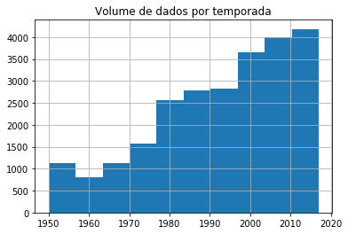

```python
ht = dados["Year"].hist()
ht.set_title('Volume de dados por temporada')
```

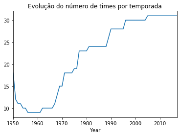

```python
NumTeam = dados[["Tm","Year"]].groupby('Year').nunique()
gr3 = NumTeam["Tm"].plot(kind = 'line')
gr3.set_title('Evolução do número de times por temporada')
```